# STAT340 Midterm - in class portion

### First (given) name:

Write here: ________________________________________

### Last (family) name:

Write here: ________________________________________

## Rules:

- You must show work for all computations (unless otherwise specified) to receive full credit.
- You do NOT need to simplify any expressions you write down.

## Points:

| MC1-3 (/6) | MC4-6 (/6) | SA1 (/4) | SA2 (/4) | SA3 (/4) | SA4 (/4) | Total (/28) |
| --- | --- | --- | --- | --- | --- | --- |

## Multiple choice questions 2pts each

### MC1

You run a test with a significance level of 0.05, and calculate a p-value of 0.134. Which of the following is a valid conclusion?

### MC2

A Monte Carlo simulation of 10k iterations resulted in the below distribution of test statistics (see plot). Which of the following test and statistic would give the lowest p-value? (Remember left-tailed means $H_a$ uses $<$ and right-tailed means $>$)

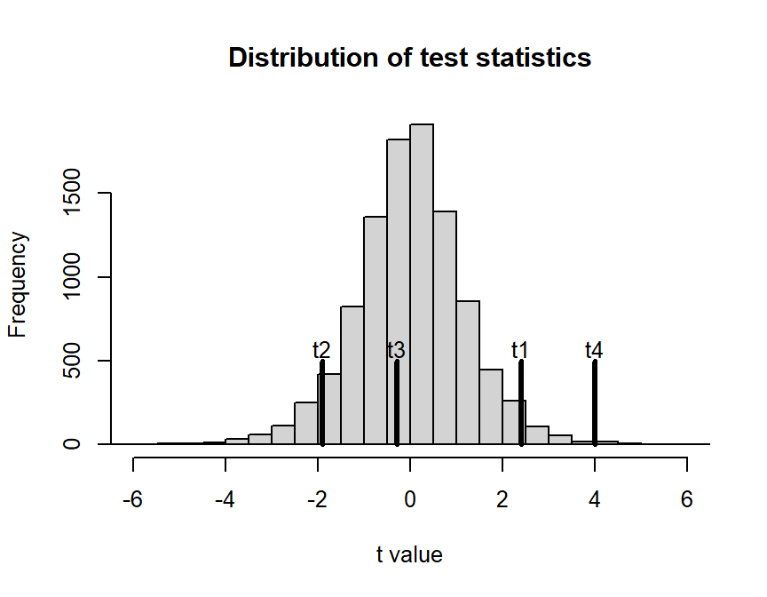

1. t2, as a two-tailed test
2. t1, as a right-tailed test
3. t3, as a left-tailed test
4. t4, as a left-tailed test
5. t1, as a two-tailed test

### MC3

A consulting company is investigating whether some new project management software will help workers be more productive than the old software. Let the null hypothesis be that the new software makes no difference, and the alternative be that the new software improves productivity. For each blank below, choose one of the following: **A: Type I error, B: Type II error, or C: Correct conclusion**

1. The new software DOES make workers more efficient, and they conclude that it DOES _____
2. The new software DOES make workers more efficient, and they conclude that it does NOT _____
3. The new software does NOT make workers more efficient, and they conclude that it DOES _____
4. The new software does NOT make workers more efficient, and they conclude that it does NOT _____

### MC4

Which is the correct ending for this statement with regards to Monte Carlo testing and estimation?

“Increasing the number of Monte Carlo runs…”

1. …gives more consistent results.
2. …lowers the chance of a Type 1 Error.
3. …increases the power of a hypothesis test.
4. …results in lower p-values.
5. …can compensate for a small amount of data.

### MC5,6

**The next two questions are based on the following plot**.

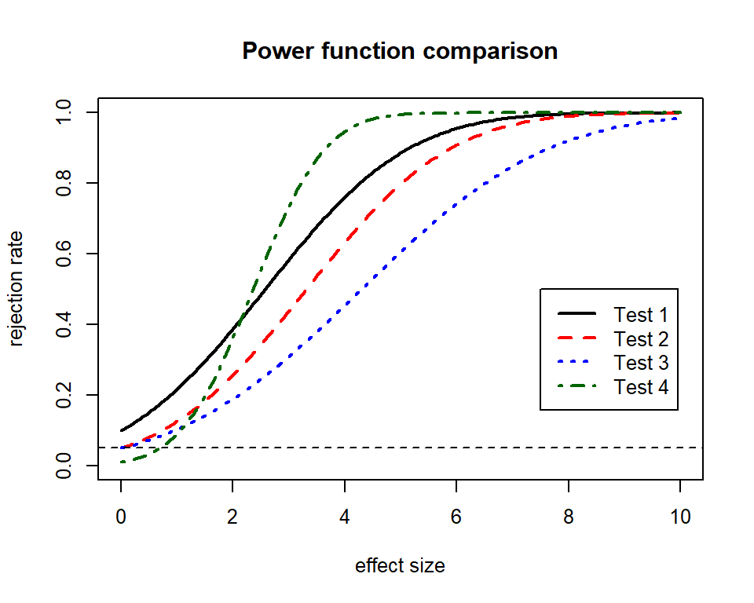

Four tests are considered to test the hypothesis $H_0: \theta = 0$ vs $H_1: \theta > 0$, at a significance level of $\alpha=0.05$. The power graph above gives the rejection rate of each test depending on the effect size (the true $\theta$ value). The nominal $\alpha=0.05$ value is shown with a horizontal line.

**MC5**: Test 2 is *always better* than which other test?

1. Test 2
2. Test 3
3. Test 4
4. All other tests
5. None of the other tests

**MC6**: Which test fails to control the type I error rate?

1. Test 1
2. Test 2
3. Test 3
4. Test 4
5. None of the tests fails

## Short answer questions 4pts each

### SA1

You work for a semiconductor manufacturing facility. Due to the high complexity of the manufacturing process, each chip has a 30% chance of being defective. Let $X=1$ if the chip is functional, and $X=0$ if the chip is defective.

1. What kind of random variable is this? Specify both the name and any necessary parameter(s).
2. Compute the expectation of this random variable. Show your work.
3. Compute the variance of this random variable. Show your work.
4. You manufacture 100 of these chips. Let Y=the number of chips that are functional. What kind of random variable is this? Again, specify the name and any necessary parameter(s).

### SA2

Let $X$ be a Poisson variable with $\lambda=20$.

1. What is the expectation of this random variable? You may state this without computation. (*Hint: think about what $\lambda$ means.*)
2. Give an example of an experiment that you can model using this random variable (be specific in your wording). This is an open ended question, so many correct responses are possible.
3. What is the probability of observing $X=24.5$ as an outcome? Give a numeric value, and briefly explain your answer.
4. What is another random variable that you can use to approximately model a Poisson? (There are two acceptable answers here). Just the name of a variable is sufficient, no need to provide parameters.

### SA3

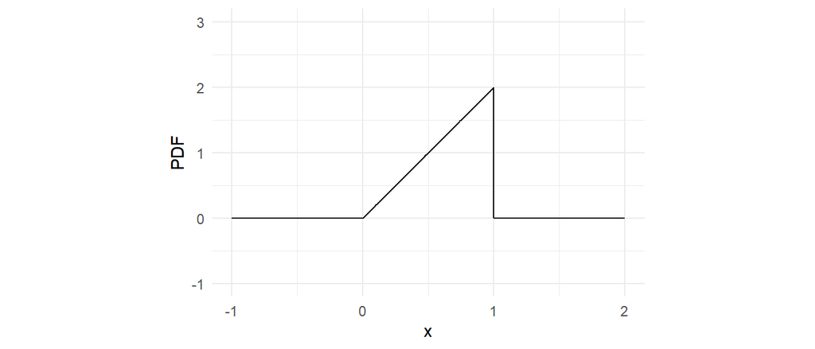

```r
pdf_x = function(x) ifelse(0<=x & x<=1,2*x,0)

ggplot() + geom_function(fun=pdf_x, n=1e5) +
  coord_fixed(ratio=.5) + theme_minimal() +
  xlim(c(-1,2)) + ylim(-1,3) + labs(x='x', y='PDF')
```

Let the functions `dx`, `px`, `qx` represent the pdf, cdf, and inverse cdf functions respectively for this random variable. Find the following, and make sure you show your work or write a brief explanation of your answers:

1. $P(X=0.5)$
2. `dx(0.5)`
3. `px(0.5)`
4. `qx(0.5)`

### SA4

Match the following pdfs to their corresponding cdfs.

pdfs:

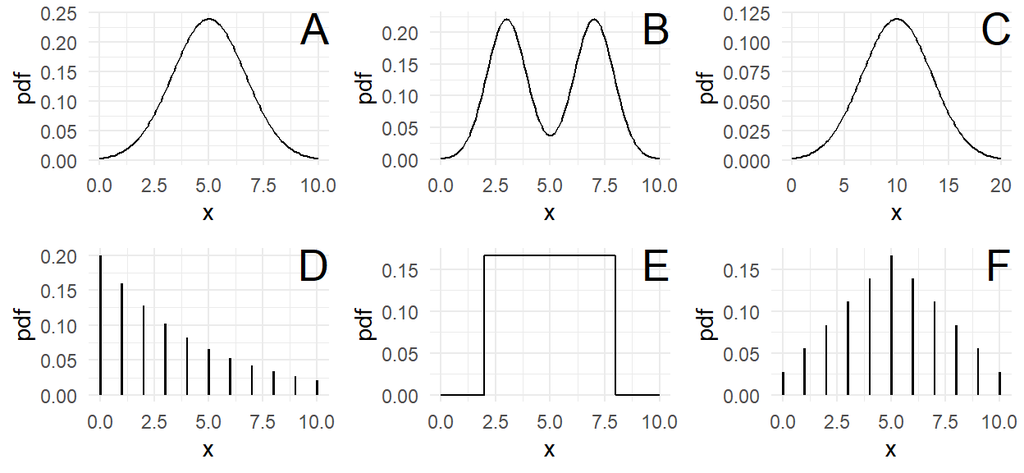

cdfs:

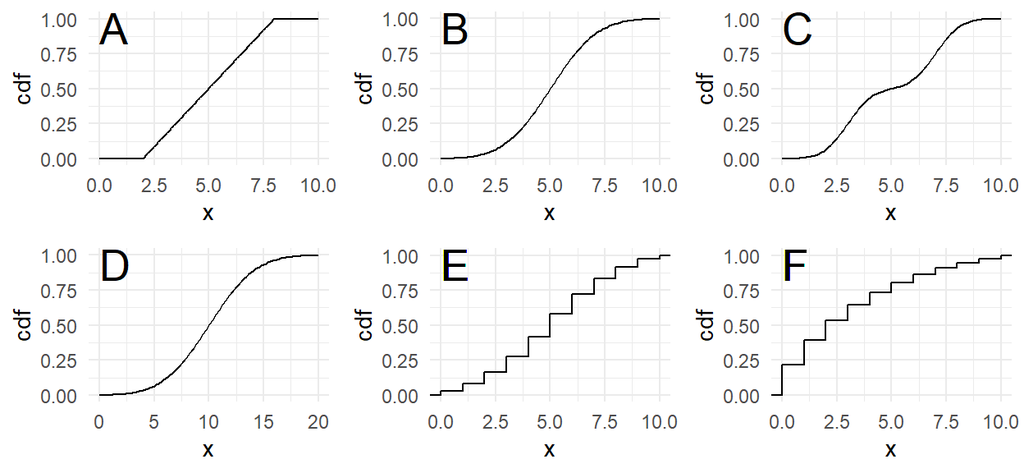

- pdf A matches cdf _____
- pdf B matches cdf _____
- pdf C matches cdf _____
- pdf D matches cdf _____
- pdf E matches cdf _____
- pdf F matches cdf _____

For this question, it’s enough just to give the correct response, but if you write a short sentence explaining your choices it may help us award partial credit.